# Sentiment Analysis

Uijeong Hwang

# 1. Run sentiment analysis

Sentiment analysis involves utilizing Natural Language Processing (NLP), along with other related techniques, to identify and quantify affective states, typically from text data. Similar to advancements we’ve observed in computer vision, recent developments have introduced well-packaged models that are user-friendly and can be readily implemented out of the box. In this chapter, we will explore a range of models, from rudimentary to more advanced ones, to practice their application in diverse scenarios.

## 1-1. Bag-of-Words (or dictionary) model: `syuzhet` package

The Bag-of-Words (BoW) model is one of the simplest techniques used in NLP and text mining to represent and analyze text data. In BoW, a text (such as a sentence or document) is represented as an unordered set or “bag” of its words, disregarding grammar, word order, and any structural elements in the text.

```r
texts_1 <- c("R is a very powerful tool for data analysis.",
           "I hate bugs in the code. They are so annoying.",
           "I love programming in R! It’s so fun.")

# syuzhet package
get_sentiment(texts_1, method='nrc')
```

```
## [1]  1 -2  2
```

```r
get_sentiment(texts_1, method='afinn')
```

```
## [1]  2 -5  7
```

```r
get_sentiment(texts_1, method='syuzhet')
```

```
## [1]  0.75 -1.50  1.50
```

```r
get_sentiment(texts_1, method='bing')
```

```
## [1]  1 -3  2
```

```r
get_nrc_sentiment(texts_1)
```

```
##   anger anticipation disgust fear joy sadness surprise trust negative positive
## 1     1            1       1    1   1       0        0     1        0        1
## 2     2            0       1    1   0       1        0     0        2        0
## 3     0            1       0    0   2       0        0     0        0        2
```

Notice that, if the models think ‘hate’ is a negative word and ‘love’ is a positive word, then how about negations? Do models consider ‘not love’ positive or negative? Let’s see the next example.

```r
texts_2 <- c("I love programming in R! It’s fun.",
             "I don't love programming in R! It’s not fun.")

# syuzhet package
get_sentiment(texts_2, method='nrc')
```

```
## [1] 2 2
```

```r
get_sentiment(texts_2, method='afinn')
```

```
## [1] 7 7
```

```r
get_sentiment(texts_2, method='syuzhet')
```

```
## [1] 1.5 1.5
```

```r
get_sentiment(texts_2, method='bing')
```

```
## [1] 2 2
```

This example above demonstrates that sentiment analysis is challenging because it involves understanding not only individual words but also the context in which they are used. When you run basic sentiment analysis that only uses a bag-of-words model, it can’t understand the context and treats every word independently. So, the words “love” and “fun” in both sentences are contributing to the positive score, and the model doesn’t consider the “not” which changes the meaning of those words.

## 1-2. Negation handling model: `sentimentr` package

Handling negation in NLP is crucial, as negation can entirely change the sentiment or meaning of a sentence. In sentiment analysis, the presence of a negation can reverse the polarity of a sentence. `sentimentr` uses the same dictionary lookup approach as the previous models, but it also takes into account **valence shifters** (i.e., words that alter or intensify the polarity of words).

```r
texts_3 <- c("I love programming in R! It’s fun.",
             "I love programming in R so much! It's really fun.",
             "I don't love programming in R! It’s not fun.",
             "I don't love programming in R at all! It’s clearly not fun.")

# by sentence
sentiment(texts_3)
```

```
##    element_id sentence_id word_count  sentiment
## 1:          1           1          5  0.3354102
## 2:          1           2          3  0.4330127
## 3:          2           1          7  0.2834734
## 4:          2           2          3  0.7794229
## 5:          3           1          6 -0.3061862
## 6:          3           2          4 -0.3750000
## 7:          4           1          8 -0.2651650
## 8:          4           2          5 -0.5590170
```

```r
# by string (a group of sentences)
sentiment_by(texts_3)
```

```
##    element_id word_count         sd ave_sentiment
## 1:          1          8 0.06901539     0.3842114
## 2:          2         10 0.35068926     0.5314481
## 3:          3         10 0.04865869    -0.3405931
## 4:          4         13 0.20778471    -0.4120910
```

We can detect not only positive/negative words, but also *negators, amplifiers (intensifiers), de-amplifiers (downtoners), and adversative conjunctions*. >You may be asked to install dependency packages to execute the command below. Follow the instructions prompted on the console.

```r
# attributes
sentiment_attributes(texts_3[1])$Attributes
```

```
##       Attribute Count      Rate
## 1:      negator     0 0.0000000
## 2:    amplifier     0 0.0000000
## 3: de-amplifier     0 0.0000000
## 4:  adversative     0 0.0000000
## 5:     negative     0 0.0000000
## 6:     positive     2 0.2857143
## 7:    polarized     2 0.2857143
```

```r
sentiment_attributes(texts_3[2])$Attributes
```

```
##       Attribute Count Rate
## 1:      negator     0  0.0
## 2:    amplifier     1  0.1
## 3: de-amplifier     0  0.0
## 4:  adversative     0  0.0
## 5:     negative     0  0.0
## 6:     positive     2  0.2
## 7:    polarized     2  0.2
```

```r
sentiment_attributes(texts_3[3])$Attributes
```

```
##       Attribute Count      Rate
## 1:      negator     2 0.2222222
## 2:    amplifier     0 0.0000000
## 3: de-amplifier     0 0.0000000
## 4:  adversative     0 0.0000000
## 5:     negative     0 0.0000000
## 6:     positive     2 0.2222222
## 7:    polarized     2 0.2222222
```

```r
sentiment_attributes(texts_3[4])$Attributes
```

```
##       Attribute Count      Rate
## 1:      negator     2 0.1666667
## 2:    amplifier     0 0.0000000
## 3: de-amplifier     0 0.0000000
## 4:  adversative     0 0.0000000
## 5:     negative     0 0.0000000
## 6:     positive     3 0.2500000
## 7:    polarized     3 0.2500000
```

## 1-3. State-of-the-art model

> In this section, we will employ a deep learning model; unfortunately, R is not the most conducive environment for training or testing such models. As expected, Python is the preferred option when it comes to deep learning due to its extensive libraries and community support. Similar to our approach in the computer vision module, we will utilize Google Colab ([link](https://colab.research.google.com/drive/1rynmZRcvB052PFaVQ2DsHrMYD1vyPN4Y?usp=sharing)). Upload (i.e., drag and drop) your Reddit data in csv format to your Colab session. You might as well use [this data](https://ujhwang.github.io/UrbanAnalytics2023/Lab/module_5/sample_reddit.csv).

In NLP, the state-of-the-art model architecture is undoubtedly **Transformer** (Check out the benchmark [here](https://paperswithcode.com/sota/sentiment-analysis-on-sst-2-binary)). The architecture was introduced in 2017 and has since become a foundation for many NLP models. The Transformer architecture has been highly influential in NLP due to its ability to handle long-range dependencies in text and its scalability, allowing the training of large models that capture intricate language patterns and semantics.

Timeline of popular Transformer model releases ([source](https://huggingface.co/blog/bert-101#1-what-is-bert-used-for)):

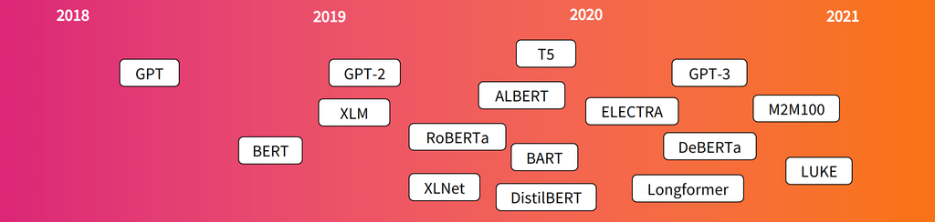

The script in Colab will demonstrate how to leverage a pre-trained **BERT** (Bidirectional Encoder Representations from Transformers) model to predict the sentiment of a given string. Developed by Google, BERT is a powerful language processing AI model designed for a range of NLP tasks.

BERT reads texts and pays attention to the surrounding words to understand the context of each word. This is the “bidirectional” part, as it learns about the word based on the words that come before and after it, unlike older models which typically read text in one direction (left to right).

Thus, BERT helps computers better understand the **meaning of words** *in a sentence*. Imagine you’re learning a new language. When you hear or see a sentence, you don’t just look at each word in isolation—you look at the words around it to understand its meaning and context. If someone says, “It’s raining cats and dogs,” you understand that it’s an expression meaning it’s raining heavily, not that pets are falling from the sky.

Let’s proceed to the [Colab](https://colab.research.google.com/drive/1rynmZRcvB052PFaVQ2DsHrMYD1vyPN4Y?usp=sharing) and analyze the sentiment of Reddit threads using the BERT model.

# 2. Output sanity check

Import the data processed from the Colab to R.

```r
reddit_sentiment <- read_csv(here('Lab', 'module_5', 'sample_reddit_bert.csv')) %>%
  drop_na('bert_label')
```

```
## ──────────────────────────────────────────────────────── Delimiter: "," chr
## (5): title, text, subreddit, url, bert_label dbl (4): ...1, timestamp,
## comments, bert_score date (1): date_utc
```

Get sentiment scores using the dictionary method for comparison.

```r
reddit_sentiment %<>%
  mutate(title = replace_na(title, ""),
         text = replace_na(text, ""),
         title_text = str_c(title, text, sep = ". "))

reddit_sentiment_dictionary <- sentiment_by(reddit_sentiment$title_text)

reddit_sentiment$sentiment_dict <- reddit_sentiment_dictionary %>% pull(ave_sentiment)
reddit_sentiment$word_count <- reddit_sentiment_dictionary %>% pull(word_count)
```

Check the correlation between the sentiment values from two different methods.

```r
reddit_sentiment %<>% mutate(bert_label_numeric = str_sub(bert_label, 1, 1) %>% as.numeric())

cor(reddit_sentiment$bert_label_numeric, reddit_sentiment$sentiment_dict)
```

```
## [1] 0.2844414
```

0.28 implies a mild positive correlation. However, in the scatter plot below, the two do not seem to be very correlated. The threads that got 4-5 stars from the BERT model are mostly below 0 (meaning negative) in the other method.

```
## Inverted geom defaults of fill and color/colour.
## To change them back, use invert_geom_defaults().
```

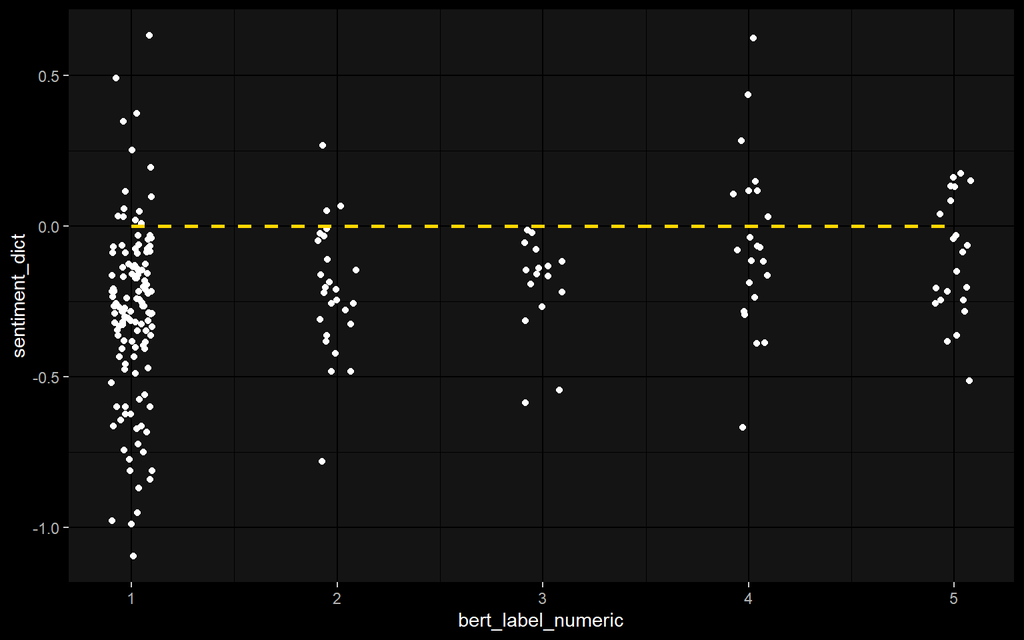

```r
ggplot(data = reddit_sentiment, aes(x = bert_label_numeric, y = sentiment_dict)) +
  geom_jitter(width = 0.1, height = 0) +
  geom_line(aes(y = 0), color = '#FFD700', lwd = 1, linetype='dashed') +
  dark_theme_grey()
```

Let’s look at some example threads and the predicted sentiment, and see which method makes more sense.

- BERT: 1 star (negative) vs. 5 stars (positive)

```r
bert_example <- reddit_sentiment %>%
  filter(bert_label_numeric %in% c(1,5)) %>%
  group_by(bert_label) %>%
  arrange(desc(bert_score)) %>%
  slice_head(n = 3) %>%
  ungroup()

# 1 star
bert_example %>% filter(bert_label_numeric == 1) %>% pull(title_text) %>% print()
```

```
## [1] "Is anyone actually scheduling flu shots NOW?!. The calls are insane.  Cold calling people and expecting them to schedule thier flu shot 2 months out right here on the spot.\n\nIs ANYONE even doing this and having any success at all??"
## [2] "Just got the most underwhelming flu shot ever. They didn\031t give me any autism, only this stupid tangerine.. "
## [3] "Why Denying Migrants Flu Shots Is a Dangerous, Foolish Move. "
```

```r
# 5 star
bert_example %>% filter(bert_label_numeric == 5) %>% pull(title_text) %>% print()
```

```
## [1] "Brave 93-year-old gets his flu shot.. "
## [2] "Brave 93-year-old gets his flu shot.. "
## [3] "Get your flu shot!!. Our pediatric wards and hospitals are completely overwhelmed. Even if you aren't worried about getting the flu yourself, get the shot. Help stop the spread. And for the love of all that's good, get it for your kids!!"
```

- Dictionary method: negative vs. positive

```r
sentimentr_example <- reddit_sentiment %>%
  mutate(sentimentr_abs = abs(sentiment_dict),
         sentimentr_binary = case_when(sentiment_dict > 0 ~ 'positive',
                                       TRUE ~ 'negative')) %>%
  group_by(sentimentr_binary) %>%
  arrange(desc(sentimentr_abs)) %>%
  slice_head(n = 3) %>%
  ungroup() %>%
  arrange(sentiment_dict)

# negative
sentimentr_example %>% filter(sentimentr_binary == 'negative') %>% pull(title_text) %>% print()
```

```
## [1] "Flu shot farce.. "
## [2] "Lady caught faking bizarre symptoms after flu shot. "
## [3] "Desiree Jennings Flu Shot victim exposed. "
```

```r
# positive
sentimentr_example %>% filter(sentimentr_binary == 'positive') %>% pull(title_text) %>% print()
```

```
## [1] "Gloria Copeland: No Need For Flu Shots Because \030Jesus Himself Gave Us The Flu Shot\031. "
## [2] "a physician gives a quick, no-nonsense summary on the pros and cons of getting the flu shot. "
## [3] "Yes flu shots not anything else. "
```

# 3. Visualization

Let’s visualize the sentiment analysis result from the BERT model.

## 3-1: Sentiment distribution

- Number of threads by sentiment category.

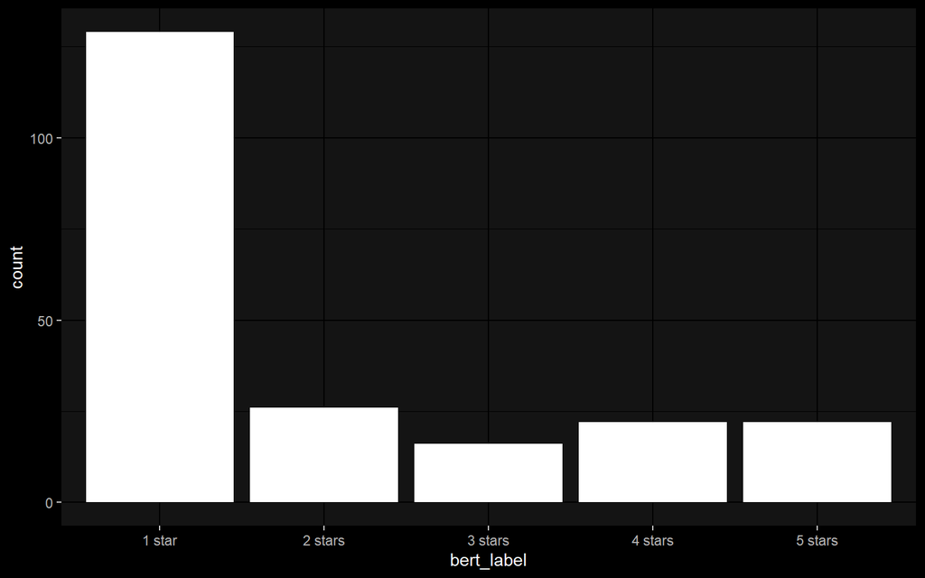

```r
reddit_sentiment %>%
  ggplot(aes(x = bert_label)) +
  geom_bar(fill = "white") +
  dark_theme_gray()
```

- Word counts by sentiment category.

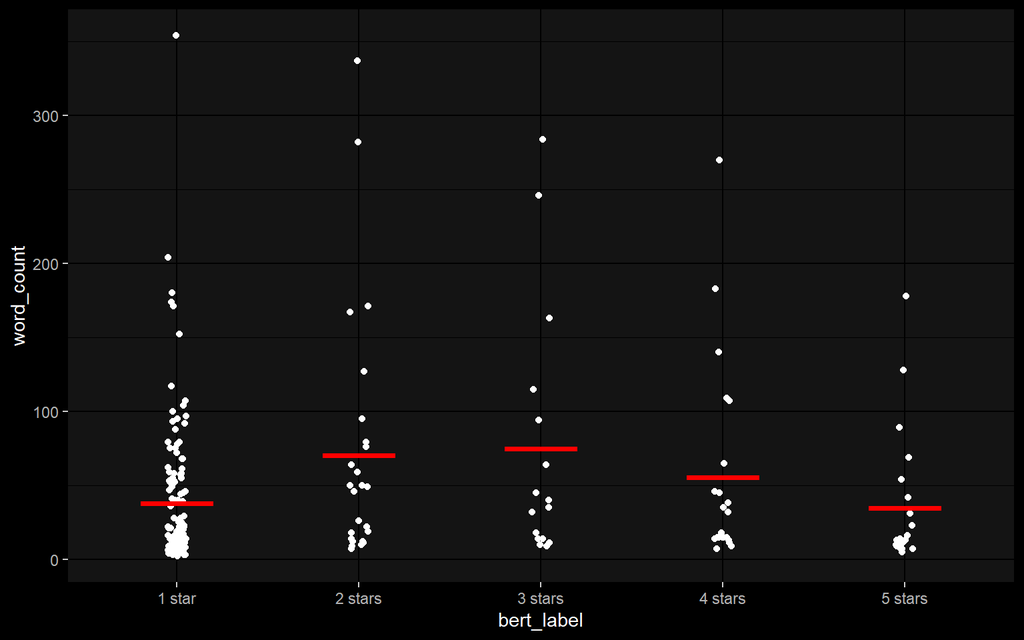

```r
reddit_sentiment %>%
  ggplot(aes(x = bert_label, y = word_count)) +
  geom_jitter(height = 0, width = 0.05) +
  stat_summary(fun = mean, geom = "crossbar", width = 0.4, color = "red") +
  dark_theme_gray()
```

- Association between a thread’s sentiment and the number of comments on the thread.

```r
reddit_sentiment_rm_outlier <- reddit_sentiment %>%
  group_by(bert_label) %>%
  filter(
    between(
      comments,
      quantile(comments, 0.25) - 1.5 * IQR(comments),
      quantile(comments, 0.75) + 1.5 * IQR(comments)))

cor.test(reddit_sentiment_rm_outlier$comments, reddit_sentiment_rm_outlier$bert_label_numeric)
```

```
##
##  Pearson's product-moment correlation
##
## data:  reddit_sentiment_rm_outlier$comments and reddit_sentiment_rm_outlier$bert_label_numeric
## t = -0.70226, df = 193, p-value = 0.4834
## alternative hypothesis: true correlation is not equal to 0
## 95 percent confidence interval:
##  -0.18965231  0.09067025
## sample estimates:
##         cor
## -0.05048531
```

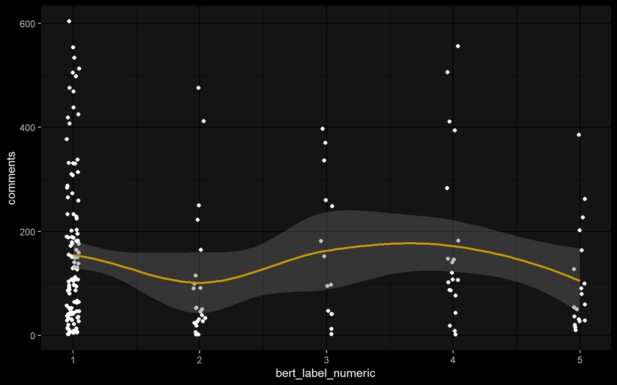

```r
reddit_sentiment_rm_outlier %>%
  ggplot(aes(x = bert_label_numeric, y = comments)) +
  geom_jitter(height = 0, width = 0.05) +
  geom_smooth(method = 'loess', span = 0.75) +
  dark_theme_gray()
```

## 3-2: Word clouds

Using word clouds, we can visualize words that are frequently seen in either positive or negative threads. Using the same code from the previous Rmd file, we tokenize the texts and remove stop words.

```r
data("stop_words")
replace_reg <- "http[s]?://[A-Za-z\\d/\\.]+|&amp;|&lt;|&gt;"

reddit_sentiment_clean <- reddit_sentiment %>%
  mutate(title_text = str_replace_all(title_text, replace_reg, "")) %>%
  unnest_tokens(word, title_text, token = "words") %>%
  anti_join(stop_words, by = "word") %>%
  filter(str_detect(word, "[a-z]")) %>%
  filter(!word %in% c('flu','shot','shots'))
```

We are not interested in words that are commonly seen in both positive and negative threads. We can identify words that are uniquely seen in either positive or negative threads using `anti_join`.

```r
reddit_sentiment_clean_negative <- reddit_sentiment_clean %>%
  filter(bert_label_numeric %in% c(1,2))
reddit_sentiment_clean_positive <- reddit_sentiment_clean %>%
  filter(bert_label_numeric %in% c(4,5))

reddit_sentiment_clean_negative_unique <- reddit_sentiment_clean_negative %>%
  anti_join(reddit_sentiment_clean_positive, by = 'word')
reddit_sentiment_clean_positive_unique <- reddit_sentiment_clean_positive %>%
  anti_join(reddit_sentiment_clean_negative, by = 'word')
```

- Words appearing in negative threads

```r
n <- 20
h <- runif(n, 0, 1) # any color
s <- runif(n, 0.6, 1) # vivid
v <- runif(n, 0.3, 0.7) # neither too dark or bright

df_hsv <- data.frame(h = h, s = s, v = v)
pal <- apply(df_hsv, 1, function(x) hsv(x['h'], x['s'], x['v']))
pal <- c(pal, rep("grey", 10000))

reddit_sentiment_clean_negative_unique %>%
  count(word, sort = TRUE) %>%
  wordcloud2(color = pal,
             minRotation = 0,
             maxRotation = 0,
             ellipticity = 0.8)
```

[interactive chart not shown]

- Words appearing in positive threads

```r
reddit_sentiment_clean_positive_unique %>%
  count(word, sort = TRUE) %>%
  wordcloud2(color = pal,
             minRotation = 0,
             maxRotation = 0,
             ellipticity = 0.8)
```

[interactive chart not shown]

## 3-3: Temporal analysis

```r
# create new columns: date, year, day_of_week, is_weekend, time
reddit_sentiment %<>%
  mutate(date = as.POSIXct(date_utc)) %>%
  filter(!is.na(date)) %>%
  mutate(year = year(date),
         day_of_week = wday(date, label = TRUE),
         is_weekend = ifelse(day_of_week %in% c("Sat", "Sun"), "Weekend", "Weekday"),
         time = timestamp %>%
           anytime(tz = anytime:::getTZ()) %>%
           str_split('-| |:') %>%
           sapply(function(x) as.numeric(x[4])))
```

Sentiment by year using a scatter plot.

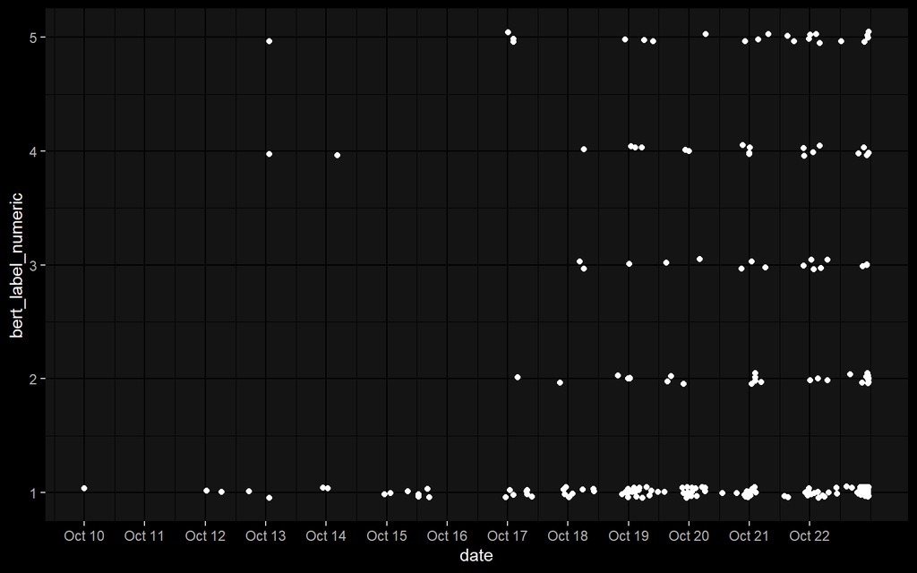

```r
reddit_sentiment %>%
  ggplot(aes(x = date, y = bert_label_numeric)) +
  geom_jitter(width = 0, height = 0.05) +
  scale_x_datetime(date_labels = "%b %y",
                   breaks = seq(min(reddit_sentiment$date, na.rm = T),
                                max(reddit_sentiment$date, na.rm = T),
                                by = "1 year")) +
  dark_theme_grey()
```

Let’s change it to a stacked bar plot.

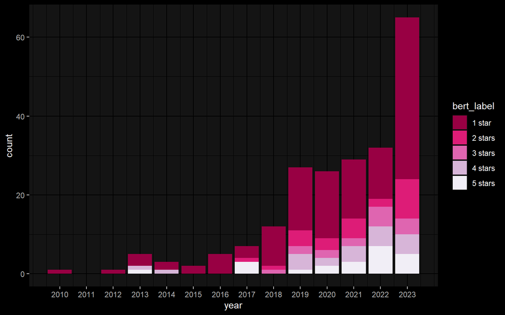

```r
# sentiment by year
reddit_sentiment %>%
  ggplot(aes(x = year, fill = bert_label)) +
  geom_bar(position = 'stack') +
  scale_x_continuous(breaks = seq(min(reddit_sentiment$year),
                                  max(reddit_sentiment$year),
                                  by = 1)) +
  scale_fill_brewer(palette = 'PuRd', direction = -1) +
  dark_theme_grey()
```

Set `position = 'fill'` to see the proportions.

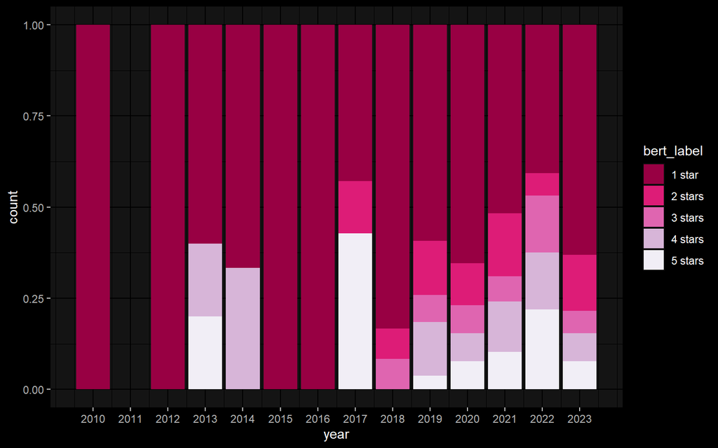

```r
# sentiment by year
reddit_sentiment %>%
  ggplot(aes(x = year, fill = bert_label)) +
  geom_bar(position = 'fill') +
  scale_x_continuous(breaks = seq(min(reddit_sentiment$year),
                                  max(reddit_sentiment$year),
                                  by = 1)) +
  scale_fill_brewer(palette = 'PuRd', direction = -1) +
  dark_theme_grey()
```

Sentiment by day of week.

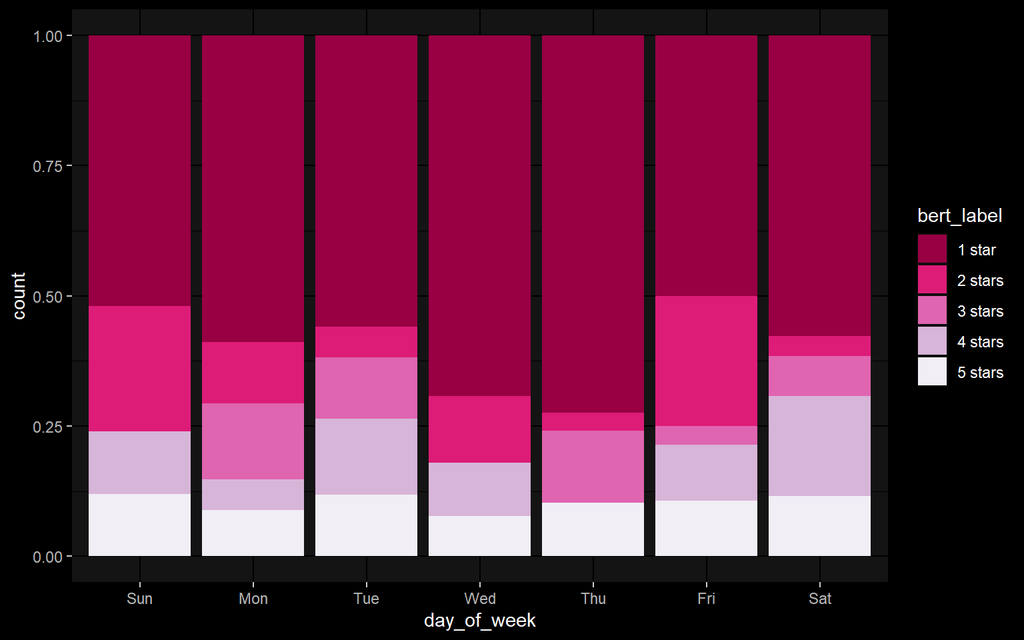

```r
# sentiment by day
reddit_sentiment %>%
  ggplot(aes(x = day_of_week, fill = bert_label)) +
  geom_bar(position = 'fill') +
  scale_fill_brewer(palette = 'PuRd', direction = -1) +
  dark_theme_grey()
```

Sentiment by time of day.

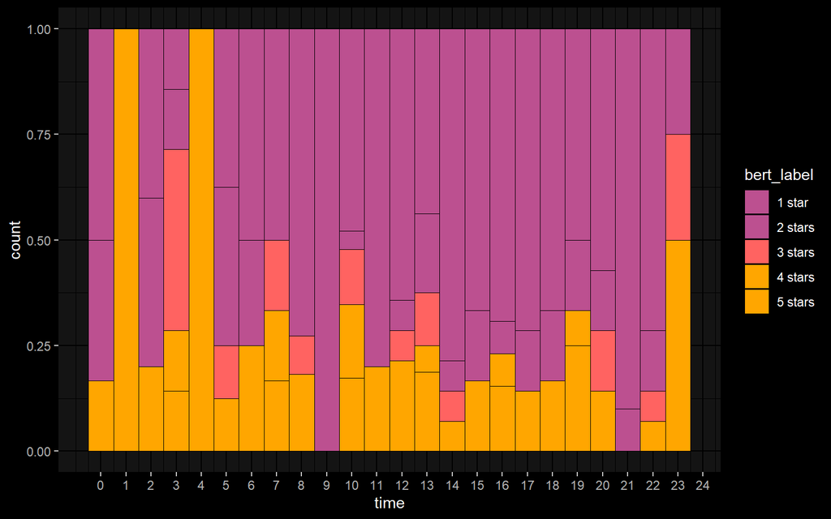

```r
reddit_sentiment %>%
  ggplot(aes(x = time, fill = bert_label)) +
  geom_histogram(bins = 24, position = 'fill', color = 'black', lwd = 0.2) +
  scale_x_continuous(breaks = seq(0, 24, by=1)) +
  scale_fill_manual(values = c('#bc5090', '#bc5090', '#ff6361', '#ffa600', '#ffa600')) +
  dark_theme_grey()
```